# Risk Factor Analysis

## Outcome Variable

**Outcome Variable:** y_rate_wtkg

## Predictor Variables

**Intervention Variable:** parity

**Adjustment Set:**

- arm
- W_mage
- meducyrs
- feducyrs
- W_mhtcm
- W_mwtkg
- W_mbmi
- vagbrth
- single
- delta_W_mage
- delta_meducyrs
- delta_feducyrs
- delta_W_mhtcm
- delta_W_mwtkg
- delta_W_mbmi
- delta_vagbrth
- delta_single

## Stratifying Variables

The analysis was stratified on these variable(s):

- agecat
- studyid
- country

## Data Summary

| agecat | studyid | country | parity | n_cell | n |
| --- | --- | --- | --- | --- | --- |
| 0-3 months | COHORTS | GUATEMALA | 1 | 103 | 798 |
| 0-3 months | COHORTS | GUATEMALA | 2 | 114 | 798 |
| 0-3 months | COHORTS | GUATEMALA | 3+ | 581 | 798 |
| 0-3 months | COHORTS | INDIA | 1 | 713 | 4147 |
| 0-3 months | COHORTS | INDIA | 2 | 1045 | 4147 |
| 0-3 months | COHORTS | INDIA | 3+ | 2389 | 4147 |
| 0-3 months | GMS-Nepal | NEPAL | 1 | 137 | 509 |
| 0-3 months | GMS-Nepal | NEPAL | 2 | 130 | 509 |
| 0-3 months | GMS-Nepal | NEPAL | 3+ | 242 | 509 |
| 0-3 months | JiVitA-3 | BANGLADESH | 1 | 6550 | 20287 |
| 0-3 months | JiVitA-3 | BANGLADESH | 2 | 6981 | 20287 |
| 0-3 months | JiVitA-3 | BANGLADESH | 3+ | 6756 | 20287 |
| 0-3 months | Keneba | GAMBIA | 1 | 192 | 1441 |
| 0-3 months | Keneba | GAMBIA | 2 | 149 | 1441 |
| 0-3 months | Keneba | GAMBIA | 3+ | 1100 | 1441 |
| 0-3 months | PROVIDE | BANGLADESH | 1 | 242 | 640 |
| 0-3 months | PROVIDE | BANGLADESH | 2 | 226 | 640 |
| 0-3 months | PROVIDE | BANGLADESH | 3+ | 172 | 640 |
| 0-3 months | SAS-CompFeed | INDIA | 1 | 346 | 1265 |
| 0-3 months | SAS-CompFeed | INDIA | 2 | 300 | 1265 |
| 0-3 months | SAS-CompFeed | INDIA | 3+ | 619 | 1265 |
| 0-3 months | TanzaniaChild2 | TANZANIA, UNITED REPUBLIC OF | 1 | 680 | 1996 |
| 0-3 months | TanzaniaChild2 | TANZANIA, UNITED REPUBLIC OF | 2 | 659 | 1996 |
| 0-3 months | TanzaniaChild2 | TANZANIA, UNITED REPUBLIC OF | 3+ | 657 | 1996 |
| 0-3 months | ZVITAMBO | ZIMBABWE | 1 | 3175 | 8171 |
| 0-3 months | ZVITAMBO | ZIMBABWE | 2 | 2534 | 8171 |
| 0-3 months | ZVITAMBO | ZIMBABWE | 3+ | 2462 | 8171 |
| 3-6 months | COHORTS | GUATEMALA | 1 | 107 | 809 |
| 3-6 months | COHORTS | GUATEMALA | 2 | 115 | 809 |
| 3-6 months | COHORTS | GUATEMALA | 3+ | 587 | 809 |

[output cut: 159 more lines]

The following strata were considered:

- agecat: 0-3 months, studyid: COHORTS, country: GUATEMALA
- agecat: 0-3 months, studyid: COHORTS, country: INDIA
- agecat: 0-3 months, studyid: GMS-Nepal, country: NEPAL
- agecat: 0-3 months, studyid: JiVitA-3, country: BANGLADESH
- agecat: 0-3 months, studyid: Keneba, country: GAMBIA
- agecat: 0-3 months, studyid: PROVIDE, country: BANGLADESH
- agecat: 0-3 months, studyid: SAS-CompFeed, country: INDIA
- agecat: 0-3 months, studyid: TanzaniaChild2, country: TANZANIA, UNITED REPUBLIC OF
- agecat: 0-3 months, studyid: ZVITAMBO, country: ZIMBABWE
- agecat: 12-15 months, studyid: COHORTS, country: GUATEMALA
- agecat: 12-15 months, studyid: GMS-Nepal, country: NEPAL
- agecat: 12-15 months, studyid: Keneba, country: GAMBIA
- agecat: 12-15 months, studyid: PROVIDE, country: BANGLADESH
- agecat: 12-15 months, studyid: SAS-CompFeed, country: INDIA
- agecat: 12-15 months, studyid: SAS-FoodSuppl, country: INDIA
- agecat: 12-15 months, studyid: TanzaniaChild2, country: TANZANIA, UNITED REPUBLIC OF
- agecat: 12-15 months, studyid: ZVITAMBO, country: ZIMBABWE
- agecat: 15-18 months, studyid: COHORTS, country: GUATEMALA
- agecat: 15-18 months, studyid: GMS-Nepal, country: NEPAL
- agecat: 15-18 months, studyid: Keneba, country: GAMBIA
- agecat: 15-18 months, studyid: PROVIDE, country: BANGLADESH
- agecat: 15-18 months, studyid: SAS-CompFeed, country: INDIA
- agecat: 15-18 months, studyid: SAS-FoodSuppl, country: INDIA
- agecat: 15-18 months, studyid: TanzaniaChild2, country: TANZANIA, UNITED REPUBLIC OF
- agecat: 15-18 months, studyid: ZVITAMBO, country: ZIMBABWE
- agecat: 18-21 months, studyid: COHORTS, country: GUATEMALA
- agecat: 18-21 months, studyid: GMS-Nepal, country: NEPAL
- agecat: 18-21 months, studyid: Keneba, country: GAMBIA
- agecat: 18-21 months, studyid: PROVIDE, country: BANGLADESH
- agecat: 18-21 months, studyid: TanzaniaChild2, country: TANZANIA, UNITED REPUBLIC OF
- agecat: 18-21 months, studyid: ZVITAMBO, country: ZIMBABWE
- agecat: 21-24 months, studyid: COHORTS, country: GUATEMALA
- agecat: 21-24 months, studyid: GMS-Nepal, country: NEPAL
- agecat: 21-24 months, studyid: Keneba, country: GAMBIA
- agecat: 21-24 months, studyid: PROVIDE, country: BANGLADESH
- agecat: 21-24 months, studyid: ZVITAMBO, country: ZIMBABWE
- agecat: 3-6 months, studyid: COHORTS, country: GUATEMALA
- agecat: 3-6 months, studyid: COHORTS, country: INDIA
- agecat: 3-6 months, studyid: GMS-Nepal, country: NEPAL
- agecat: 3-6 months, studyid: JiVitA-3, country: BANGLADESH
- agecat: 3-6 months, studyid: Keneba, country: GAMBIA
- agecat: 3-6 months, studyid: PROVIDE, country: BANGLADESH
- agecat: 3-6 months, studyid: SAS-CompFeed, country: INDIA
- agecat: 3-6 months, studyid: TanzaniaChild2, country: TANZANIA, UNITED REPUBLIC OF
- agecat: 3-6 months, studyid: ZVITAMBO, country: ZIMBABWE
- agecat: 6-9 months, studyid: COHORTS, country: GUATEMALA
- agecat: 6-9 months, studyid: COHORTS, country: INDIA
- agecat: 6-9 months, studyid: GMS-Nepal, country: NEPAL
- agecat: 6-9 months, studyid: Keneba, country: GAMBIA
- agecat: 6-9 months, studyid: PROVIDE, country: BANGLADESH
- agecat: 6-9 months, studyid: SAS-CompFeed, country: INDIA
- agecat: 6-9 months, studyid: SAS-FoodSuppl, country: INDIA
- agecat: 6-9 months, studyid: TanzaniaChild2, country: TANZANIA, UNITED REPUBLIC OF
- agecat: 6-9 months, studyid: ZVITAMBO, country: ZIMBABWE
- agecat: 9-12 months, studyid: COHORTS, country: GUATEMALA
- agecat: 9-12 months, studyid: COHORTS, country: INDIA
- agecat: 9-12 months, studyid: GMS-Nepal, country: NEPAL
- agecat: 9-12 months, studyid: Keneba, country: GAMBIA
- agecat: 9-12 months, studyid: PROVIDE, country: BANGLADESH
- agecat: 9-12 months, studyid: SAS-CompFeed, country: INDIA
- agecat: 9-12 months, studyid: SAS-FoodSuppl, country: INDIA
- agecat: 9-12 months, studyid: TanzaniaChild2, country: TANZANIA, UNITED REPUBLIC OF
- agecat: 9-12 months, studyid: ZVITAMBO, country: ZIMBABWE

### Dropped Strata

Some strata were dropped due to rare outcomes:

- agecat: 6-9 months, studyid: SAS-FoodSuppl, country: INDIA
- agecat: 9-12 months, studyid: SAS-FoodSuppl, country: INDIA
- agecat: 12-15 months, studyid: SAS-FoodSuppl, country: INDIA
- agecat: 15-18 months, studyid: SAS-FoodSuppl, country: INDIA
- agecat: 18-21 months, studyid: TanzaniaChild2, country: TANZANIA, UNITED REPUBLIC OF

## Methods Detail

We’re interested in the causal parameters $E[Y_a]$ for all values of $a \in \mathcal{A}$. These parameters represent the mean outcome if, possibly contrary to fact, we intervened to set all units to have $A=a$. Under the randomization and positivity assumptions, these are identified by the statistical parameters $\psi_a=E_W[E_{Y|A,W}(Y|A=a,W)]$. In addition, we’re interested in the mean of $Y$, $E[Y]$ under no intervention (the observed mean). We will estimate these parameters by using SuperLearner to fit the relevant likelihood factors – $E_{Y|A,W}(Y|A=a,W)$ and $p(A=a|W)$, and then updating our likelihood fit using a joint TMLE.

For unadjusted analyses ($W=\{\}$), initial likelihoods were estimated using Lrnr_glm to estimate the simple $E(Y|A)$ and Lrnr_mean to estimate $p(A)$. For adjusted analyses, a small library containing Lrnr_glmnet, Lrnr_xgboost, and Lrnr_mean was used.

Having estimated these parameters, we will then use the delta method to estimate relative risks and attributable risks relative to a prespecified baseline level of $A$.

# Results Detail

## Results Plots

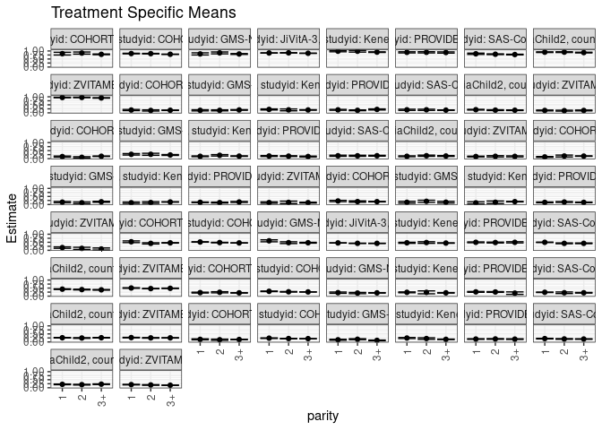

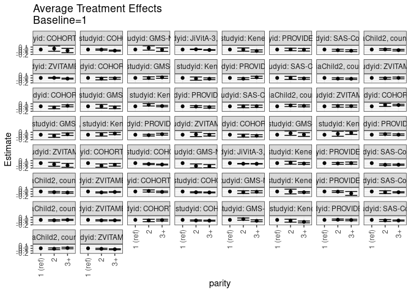

[figure not shown]

## Results Table

### Parameter: TSM

| agecat | studyid | country | intervention_level | baseline_level | estimate | ci_lower | ci_upper |
| --- | --- | --- | --- | --- | --- | --- | --- |
| 0-3 months | COHORTS | GUATEMALA | 1 | NA | 0.8324752 | 0.7479527 | 0.9169977 |
| 0-3 months | COHORTS | GUATEMALA | 2 | NA | 0.8696771 | 0.8035939 | 0.9357604 |
| 0-3 months | COHORTS | GUATEMALA | 3+ | NA | 0.7906042 | 0.7672232 | 0.8139851 |
| 0-3 months | COHORTS | INDIA | 1 | NA | 0.8385250 | 0.8201878 | 0.8568621 |
| 0-3 months | COHORTS | INDIA | 2 | NA | 0.8340666 | 0.8172518 | 0.8508814 |
| 0-3 months | COHORTS | INDIA | 3+ | NA | 0.7949636 | 0.7859916 | 0.8039357 |
| 0-3 months | GMS-Nepal | NEPAL | 1 | NA | 0.8169638 | 0.7506751 | 0.8832525 |
| 0-3 months | GMS-Nepal | NEPAL | 2 | NA | 0.8796023 | 0.8216397 | 0.9375650 |
| 0-3 months | GMS-Nepal | NEPAL | 3+ | NA | 0.8122910 | 0.7847541 | 0.8398279 |
| 0-3 months | JiVitA-3 | BANGLADESH | 1 | NA | 0.8747542 | 0.8660628 | 0.8834457 |
| 0-3 months | JiVitA-3 | BANGLADESH | 2 | NA | 0.8825727 | 0.8752864 | 0.8898590 |
| 0-3 months | JiVitA-3 | BANGLADESH | 3+ | NA | 0.8568595 | 0.8498287 | 0.8638903 |
| 0-3 months | Keneba | GAMBIA | 1 | NA | 0.9845128 | 0.9477163 | 1.0213092 |
| 0-3 months | Keneba | GAMBIA | 2 | NA | 0.9828364 | 0.9284521 | 1.0372208 |
| 0-3 months | Keneba | GAMBIA | 3+ | NA | 0.9275085 | 0.9069811 | 0.9480360 |
| 0-3 months | PROVIDE | BANGLADESH | 1 | NA | 0.9132547 | 0.8779877 | 0.9485218 |
| 0-3 months | PROVIDE | BANGLADESH | 2 | NA | 0.9166689 | 0.8783817 | 0.9549561 |
| 0-3 months | PROVIDE | BANGLADESH | 3+ | NA | 0.9041687 | 0.8652869 | 0.9430504 |
| 0-3 months | SAS-CompFeed | INDIA | 1 | NA | 0.8246377 | 0.7829670 | 0.8663084 |
| 0-3 months | SAS-CompFeed | INDIA | 2 | NA | 0.7974409 | 0.7739219 | 0.8209600 |
| 0-3 months | SAS-CompFeed | INDIA | 3+ | NA | 0.7771966 | 0.7550925 | 0.7993007 |
| 0-3 months | TanzaniaChild2 | TANZANIA, UNITED REPUBLIC OF | 1 | NA | 0.9240728 | 0.9014279 | 0.9467178 |
| 0-3 months | TanzaniaChild2 | TANZANIA, UNITED REPUBLIC OF | 2 | NA | 0.9277153 | 0.9040050 | 0.9514255 |
| 0-3 months | TanzaniaChild2 | TANZANIA, UNITED REPUBLIC OF | 3+ | NA | 0.8989321 | 0.8765940 | 0.9212702 |
| 0-3 months | ZVITAMBO | ZIMBABWE | 1 | NA | 0.9562547 | 0.9427019 | 0.9698074 |
| 0-3 months | ZVITAMBO | ZIMBABWE | 2 | NA | 0.9594255 | 0.9450935 | 0.9737575 |
| 0-3 months | ZVITAMBO | ZIMBABWE | 3+ | NA | 0.9284187 | 0.9141423 | 0.9426951 |
| 3-6 months | COHORTS | GUATEMALA | 1 | NA | 0.5314053 | 0.4774725 | 0.5853380 |
| 3-6 months | COHORTS | GUATEMALA | 2 | NA | 0.4316308 | 0.3921526 | 0.4711091 |
| 3-6 months | COHORTS | GUATEMALA | 3+ | NA | 0.4635623 | 0.4497060 | 0.4774186 |

[output cut: 144 more lines]

### Parameter: E(Y)

| agecat | studyid | country | intervention_level | baseline_level | estimate | ci_lower | ci_upper |
| --- | --- | --- | --- | --- | --- | --- | --- |
| 0-3 months | COHORTS | GUATEMALA | NA | NA | 0.7980090 | 0.7812054 | 0.8148126 |
| 0-3 months | COHORTS | INDIA | NA | NA | 0.8079112 | 0.8020259 | 0.8137966 |
| 0-3 months | GMS-Nepal | NEPAL | NA | NA | 0.8270122 | 0.8100415 | 0.8439828 |
| 0-3 months | JiVitA-3 | BANGLADESH | NA | NA | 0.8710463 | 0.8679643 | 0.8741282 |
| 0-3 months | Keneba | GAMBIA | NA | NA | 0.9250728 | 0.9133367 | 0.9368088 |
| 0-3 months | PROVIDE | BANGLADESH | NA | NA | 0.9016472 | 0.8868914 | 0.9164029 |
| 0-3 months | SAS-CompFeed | INDIA | NA | NA | 0.7908355 | 0.7705160 | 0.8111550 |
| 0-3 months | TanzaniaChild2 | TANZANIA, UNITED REPUBLIC OF | NA | NA | 0.9222782 | 0.9120605 | 0.9324960 |
| 0-3 months | ZVITAMBO | ZIMBABWE | NA | NA | 0.9497140 | 0.9445866 | 0.9548414 |
| 3-6 months | COHORTS | GUATEMALA | NA | NA | 0.4605000 | 0.4496523 | 0.4713476 |
| 3-6 months | COHORTS | INDIA | NA | NA | 0.4724963 | 0.4676809 | 0.4773116 |
| 3-6 months | GMS-Nepal | NEPAL | NA | NA | 0.4976117 | 0.4838029 | 0.5114205 |
| 3-6 months | JiVitA-3 | BANGLADESH | NA | NA | 0.4413738 | 0.4384031 | 0.4443445 |
| 3-6 months | Keneba | GAMBIA | NA | NA | 0.4451759 | 0.4348013 | 0.4555506 |
| 3-6 months | PROVIDE | BANGLADESH | NA | NA | 0.4890611 | 0.4760060 | 0.5021163 |
| 3-6 months | SAS-CompFeed | INDIA | NA | NA | 0.4502075 | 0.4368094 | 0.4636057 |
| 3-6 months | TanzaniaChild2 | TANZANIA, UNITED REPUBLIC OF | NA | NA | 0.4202993 | 0.4115402 | 0.4290585 |
| 3-6 months | ZVITAMBO | ZIMBABWE | NA | NA | 0.4783450 | 0.4738196 | 0.4828705 |
| 6-9 months | COHORTS | GUATEMALA | NA | NA | 0.2137898 | 0.2041068 | 0.2234728 |
| 6-9 months | COHORTS | INDIA | NA | NA | 0.2666046 | 0.2615353 | 0.2716740 |
| 6-9 months | GMS-Nepal | NEPAL | NA | NA | 0.1874500 | 0.1753777 | 0.1995223 |
| 6-9 months | Keneba | GAMBIA | NA | NA | 0.2054643 | 0.1921119 | 0.2188168 |
| 6-9 months | PROVIDE | BANGLADESH | NA | NA | 0.2491653 | 0.2371134 | 0.2612172 |
| 6-9 months | SAS-CompFeed | INDIA | NA | NA | 0.2097690 | 0.1949147 | 0.2246234 |
| 6-9 months | TanzaniaChild2 | TANZANIA, UNITED REPUBLIC OF | NA | NA | 0.2555255 | 0.2465533 | 0.2644978 |
| 6-9 months | ZVITAMBO | ZIMBABWE | NA | NA | 0.2583530 | 0.2538536 | 0.2628524 |
| 9-12 months | COHORTS | GUATEMALA | NA | NA | 0.1559960 | 0.1474406 | 0.1645514 |
| 9-12 months | COHORTS | INDIA | NA | NA | 0.2135824 | 0.2082338 | 0.2189309 |
| 9-12 months | GMS-Nepal | NEPAL | NA | NA | 0.1439907 | 0.1312935 | 0.1566879 |
| 9-12 months | Keneba | GAMBIA | NA | NA | 0.1627974 | 0.1505170 | 0.1750777 |
| 9-12 months | PROVIDE | BANGLADESH | NA | NA | 0.1775316 | 0.1681968 | 0.1868664 |
| 9-12 months | SAS-CompFeed | INDIA | NA | NA | 0.1943224 | 0.1874198 | 0.2012249 |
| 9-12 months | TanzaniaChild2 | TANZANIA, UNITED REPUBLIC OF | NA | NA | 0.2048196 | 0.1946367 | 0.2150025 |
| 9-12 months | ZVITAMBO | ZIMBABWE | NA | NA | 0.1800863 | 0.1755557 | 0.1846170 |
| 12-15 months | COHORTS | GUATEMALA | NA | NA | 0.1508808 | 0.1417226 | 0.1600389 |
| 12-15 months | GMS-Nepal | NEPAL | NA | NA | 0.1721075 | 0.1589812 | 0.1852337 |
| 12-15 months | Keneba | GAMBIA | NA | NA | 0.1824116 | 0.1716763 | 0.1931470 |
| 12-15 months | PROVIDE | BANGLADESH | NA | NA | 0.1800324 | 0.1683272 | 0.1917375 |
| 12-15 months | SAS-CompFeed | INDIA | NA | NA | 0.1851225 | 0.1777268 | 0.1925183 |
| 12-15 months | TanzaniaChild2 | TANZANIA, UNITED REPUBLIC OF | NA | NA | 0.1741189 | 0.1626692 | 0.1855686 |
| 12-15 months | ZVITAMBO | ZIMBABWE | NA | NA | 0.1499254 | 0.1419751 | 0.1578757 |
| 15-18 months | COHORTS | GUATEMALA | NA | NA | 0.1402124 | 0.1291753 | 0.1512496 |
| 15-18 months | GMS-Nepal | NEPAL | NA | NA | 0.2347736 | 0.2195239 | 0.2500233 |
| 15-18 months | Keneba | GAMBIA | NA | NA | 0.1607263 | 0.1498189 | 0.1716337 |
| 15-18 months | PROVIDE | BANGLADESH | NA | NA | 0.1563514 | 0.1445823 | 0.1681205 |
| 15-18 months | SAS-CompFeed | INDIA | NA | NA | 0.1775870 | 0.1644275 | 0.1907466 |
| 15-18 months | TanzaniaChild2 | TANZANIA, UNITED REPUBLIC OF | NA | NA | 0.1694110 | 0.1549701 | 0.1838520 |
| 15-18 months | ZVITAMBO | ZIMBABWE | NA | NA | 0.1337260 | 0.1231139 | 0.1443380 |
| 18-21 months | COHORTS | GUATEMALA | NA | NA | 0.1633163 | 0.1526500 | 0.1739826 |
| 18-21 months | GMS-Nepal | NEPAL | NA | NA | 0.1423948 | 0.1268654 | 0.1579242 |
| 18-21 months | Keneba | GAMBIA | NA | NA | 0.1560829 | 0.1446249 | 0.1675408 |
| 18-21 months | PROVIDE | BANGLADESH | NA | NA | 0.1324882 | 0.1210438 | 0.1439326 |
| 18-21 months | ZVITAMBO | ZIMBABWE | NA | NA | 0.1209531 | 0.1039197 | 0.1379866 |
| 21-24 months | COHORTS | GUATEMALA | NA | NA | 0.1840047 | 0.1740929 | 0.1939165 |
| 21-24 months | GMS-Nepal | NEPAL | NA | NA | 0.1768175 | 0.1523979 | 0.2012370 |
| 21-24 months | Keneba | GAMBIA | NA | NA | 0.1676062 | 0.1561278 | 0.1790846 |
| 21-24 months | PROVIDE | BANGLADESH | NA | NA | 0.1419705 | 0.1305335 | 0.1534075 |
| 21-24 months | ZVITAMBO | ZIMBABWE | NA | NA | 0.1090935 | 0.0811882 | 0.1369987 |

### Parameter: ATE

| agecat | studyid | country | intervention_level | baseline_level | estimate | ci_lower | ci_upper |
| --- | --- | --- | --- | --- | --- | --- | --- |
| 0-3 months | COHORTS | GUATEMALA | 1 | 1 | 0.0000000 | 0.0000000 | 0.0000000 |
| 0-3 months | COHORTS | GUATEMALA | 2 | 1 | 0.0372019 | -0.0701274 | 0.1445312 |
| 0-3 months | COHORTS | GUATEMALA | 3+ | 1 | -0.0418710 | -0.1296257 | 0.0458837 |
| 0-3 months | COHORTS | INDIA | 1 | 1 | 0.0000000 | 0.0000000 | 0.0000000 |
| 0-3 months | COHORTS | INDIA | 2 | 1 | -0.0044584 | -0.0293293 | 0.0204125 |
| 0-3 months | COHORTS | INDIA | 3+ | 1 | -0.0435613 | -0.0639832 | -0.0231394 |
| 0-3 months | GMS-Nepal | NEPAL | 1 | 1 | 0.0000000 | 0.0000000 | 0.0000000 |
| 0-3 months | GMS-Nepal | NEPAL | 2 | 1 | 0.0626385 | -0.0256400 | 0.1509170 |
| 0-3 months | GMS-Nepal | NEPAL | 3+ | 1 | -0.0046728 | -0.0764383 | 0.0670927 |
| 0-3 months | JiVitA-3 | BANGLADESH | 1 | 1 | 0.0000000 | 0.0000000 | 0.0000000 |
| 0-3 months | JiVitA-3 | BANGLADESH | 2 | 1 | 0.0078185 | -0.0037825 | 0.0194195 |
| 0-3 months | JiVitA-3 | BANGLADESH | 3+ | 1 | -0.0178947 | -0.0292145 | -0.0065750 |
| 0-3 months | Keneba | GAMBIA | 1 | 1 | 0.0000000 | 0.0000000 | 0.0000000 |
| 0-3 months | Keneba | GAMBIA | 2 | 1 | -0.0016763 | -0.0673915 | 0.0640389 |
| 0-3 months | Keneba | GAMBIA | 3+ | 1 | -0.0570043 | -0.0991557 | -0.0148528 |
| 0-3 months | PROVIDE | BANGLADESH | 1 | 1 | 0.0000000 | 0.0000000 | 0.0000000 |
| 0-3 months | PROVIDE | BANGLADESH | 2 | 1 | 0.0034141 | -0.0487140 | 0.0555423 |
| 0-3 months | PROVIDE | BANGLADESH | 3+ | 1 | -0.0090861 | -0.0616241 | 0.0434520 |
| 0-3 months | SAS-CompFeed | INDIA | 1 | 1 | 0.0000000 | 0.0000000 | 0.0000000 |
| 0-3 months | SAS-CompFeed | INDIA | 2 | 1 | -0.0271968 | -0.0668296 | 0.0124360 |
| 0-3 months | SAS-CompFeed | INDIA | 3+ | 1 | -0.0474411 | -0.0843163 | -0.0105659 |
| 0-3 months | TanzaniaChild2 | TANZANIA, UNITED REPUBLIC OF | 1 | 1 | 0.0000000 | 0.0000000 | 0.0000000 |
| 0-3 months | TanzaniaChild2 | TANZANIA, UNITED REPUBLIC OF | 2 | 1 | 0.0036424 | -0.0292571 | 0.0365420 |
| 0-3 months | TanzaniaChild2 | TANZANIA, UNITED REPUBLIC OF | 3+ | 1 | -0.0251408 | -0.0570708 | 0.0067893 |
| 0-3 months | ZVITAMBO | ZIMBABWE | 1 | 1 | 0.0000000 | 0.0000000 | 0.0000000 |
| 0-3 months | ZVITAMBO | ZIMBABWE | 2 | 1 | 0.0031709 | -0.0165395 | 0.0228812 |
| 0-3 months | ZVITAMBO | ZIMBABWE | 3+ | 1 | -0.0278360 | -0.0475021 | -0.0081699 |
| 3-6 months | COHORTS | GUATEMALA | 1 | 1 | 0.0000000 | 0.0000000 | 0.0000000 |
| 3-6 months | COHORTS | GUATEMALA | 2 | 1 | -0.0997744 | -0.1666021 | -0.0329467 |
| 3-6 months | COHORTS | GUATEMALA | 3+ | 1 | -0.0678429 | -0.1235386 | -0.0121473 |

[output cut: 144 more lines]

### Parameter: PAR

| agecat | studyid | country | intervention_level | baseline_level | estimate | ci_lower | ci_upper |
| --- | --- | --- | --- | --- | --- | --- | --- |
| 0-3 months | COHORTS | GUATEMALA | 1 | NA | -0.0344662 | -0.1169881 | 0.0480557 |
| 0-3 months | COHORTS | INDIA | 1 | NA | -0.0306137 | -0.0483307 | -0.0128968 |
| 0-3 months | GMS-Nepal | NEPAL | 1 | NA | 0.0100484 | -0.0526956 | 0.0727923 |
| 0-3 months | JiVitA-3 | BANGLADESH | 1 | NA | -0.0037080 | -0.0121371 | 0.0047211 |
| 0-3 months | Keneba | GAMBIA | 1 | NA | -0.0594400 | -0.0957493 | -0.0231307 |
| 0-3 months | PROVIDE | BANGLADESH | 1 | NA | -0.0116076 | -0.0433167 | 0.0201016 |
| 0-3 months | SAS-CompFeed | INDIA | 1 | NA | -0.0338022 | -0.0610704 | -0.0065341 |
| 0-3 months | TanzaniaChild2 | TANZANIA, UNITED REPUBLIC OF | 1 | NA | -0.0017946 | -0.0223351 | 0.0187459 |
| 0-3 months | ZVITAMBO | ZIMBABWE | 1 | NA | -0.0065406 | -0.0192744 | 0.0061931 |
| 3-6 months | COHORTS | GUATEMALA | 1 | NA | -0.0709053 | -0.1236281 | -0.0181825 |
| 3-6 months | COHORTS | INDIA | 1 | NA | -0.0453160 | -0.0594046 | -0.0312274 |
| 3-6 months | GMS-Nepal | NEPAL | 1 | NA | -0.0933937 | -0.1511703 | -0.0356172 |
| 3-6 months | JiVitA-3 | BANGLADESH | 1 | NA | -0.0185920 | -0.0250096 | -0.0121744 |
| 3-6 months | Keneba | GAMBIA | 1 | NA | -0.0222541 | -0.0544725 | 0.0099642 |
| 3-6 months | PROVIDE | BANGLADESH | 1 | NA | -0.0083100 | -0.0317209 | 0.0151009 |
| 3-6 months | SAS-CompFeed | INDIA | 1 | NA | -0.0475744 | -0.0644590 | -0.0306898 |
| 3-6 months | TanzaniaChild2 | TANZANIA, UNITED REPUBLIC OF | 1 | NA | -0.0133761 | -0.0317185 | 0.0049663 |
| 3-6 months | ZVITAMBO | ZIMBABWE | 1 | NA | -0.0266596 | -0.0429228 | -0.0103965 |
| 6-9 months | COHORTS | GUATEMALA | 1 | NA | -0.0050184 | -0.0286464 | 0.0186097 |
| 6-9 months | COHORTS | INDIA | 1 | NA | -0.0321791 | -0.0470854 | -0.0172728 |
| 6-9 months | GMS-Nepal | NEPAL | 1 | NA | -0.0276991 | -0.0656520 | 0.0102538 |
| 6-9 months | Keneba | GAMBIA | 1 | NA | -0.0301619 | -0.0573025 | -0.0030214 |
| 6-9 months | PROVIDE | BANGLADESH | 1 | NA | -0.0143572 | -0.0374017 | 0.0086872 |
| 6-9 months | SAS-CompFeed | INDIA | 1 | NA | -0.0274506 | -0.0478943 | -0.0070068 |
| 6-9 months | TanzaniaChild2 | TANZANIA, UNITED REPUBLIC OF | 1 | NA | -0.0057874 | -0.0207466 | 0.0091717 |
| 6-9 months | ZVITAMBO | ZIMBABWE | 1 | NA | -0.0127702 | -0.0281392 | 0.0025989 |
| 9-12 months | COHORTS | GUATEMALA | 1 | NA | -0.0048838 | -0.0360870 | 0.0263194 |
| 9-12 months | COHORTS | INDIA | 1 | NA | -0.0206902 | -0.0390312 | -0.0023491 |
| 9-12 months | GMS-Nepal | NEPAL | 1 | NA | 0.0088191 | -0.0222309 | 0.0398691 |
| 9-12 months | Keneba | GAMBIA | 1 | NA | -0.0803993 | -0.1127405 | -0.0480581 |
| 9-12 months | PROVIDE | BANGLADESH | 1 | NA | -0.0020183 | -0.0197496 | 0.0157131 |
| 9-12 months | SAS-CompFeed | INDIA | 1 | NA | -0.0127205 | -0.0358524 | 0.0104114 |
| 9-12 months | TanzaniaChild2 | TANZANIA, UNITED REPUBLIC OF | 1 | NA | -0.0072874 | -0.0272371 | 0.0126622 |
| 9-12 months | ZVITAMBO | ZIMBABWE | 1 | NA | -0.0157772 | -0.0293704 | -0.0021840 |
| 12-15 months | COHORTS | GUATEMALA | 1 | NA | -0.0246049 | -0.0595455 | 0.0103356 |
| 12-15 months | GMS-Nepal | NEPAL | 1 | NA | 0.0158076 | -0.0189666 | 0.0505818 |
| 12-15 months | Keneba | GAMBIA | 1 | NA | -0.0310692 | -0.0632913 | 0.0011530 |
| 12-15 months | PROVIDE | BANGLADESH | 1 | NA | -0.0069972 | -0.0315725 | 0.0175781 |
| 12-15 months | SAS-CompFeed | INDIA | 1 | NA | -0.0052759 | -0.0429915 | 0.0324398 |
| 12-15 months | TanzaniaChild2 | TANZANIA, UNITED REPUBLIC OF | 1 | NA | -0.0221889 | -0.0403874 | -0.0039903 |
| 12-15 months | ZVITAMBO | ZIMBABWE | 1 | NA | 0.0008091 | -0.0226420 | 0.0242602 |
| 15-18 months | COHORTS | GUATEMALA | 1 | NA | 0.0098444 | -0.0246748 | 0.0443636 |
| 15-18 months | GMS-Nepal | NEPAL | 1 | NA | -0.0364683 | -0.0802037 | 0.0072671 |
| 15-18 months | Keneba | GAMBIA | 1 | NA | 0.0131047 | -0.0114565 | 0.0376659 |
| 15-18 months | PROVIDE | BANGLADESH | 1 | NA | -0.0098743 | -0.0348310 | 0.0150824 |
| 15-18 months | SAS-CompFeed | INDIA | 1 | NA | -0.0035494 | -0.0372112 | 0.0301124 |
| 15-18 months | TanzaniaChild2 | TANZANIA, UNITED REPUBLIC OF | 1 | NA | 0.0217244 | -0.0024065 | 0.0458553 |
| 15-18 months | ZVITAMBO | ZIMBABWE | 1 | NA | 0.0003294 | -0.0222052 | 0.0228641 |
| 18-21 months | COHORTS | GUATEMALA | 1 | NA | 0.0550815 | 0.0287791 | 0.0813839 |
| 18-21 months | GMS-Nepal | NEPAL | 1 | NA | -0.0050270 | -0.0430301 | 0.0329760 |
| 18-21 months | Keneba | GAMBIA | 1 | NA | 0.0480698 | 0.0043749 | 0.0917646 |
| 18-21 months | PROVIDE | BANGLADESH | 1 | NA | -0.0032092 | -0.0192509 | 0.0128325 |
| 18-21 months | ZVITAMBO | ZIMBABWE | 1 | NA | 0.0021841 | -0.0356381 | 0.0400064 |
| 21-24 months | COHORTS | GUATEMALA | 1 | NA | -0.0340088 | -0.0733476 | 0.0053300 |
| 21-24 months | GMS-Nepal | NEPAL | 1 | NA | 0.0386643 | -0.0141335 | 0.0914621 |
| 21-24 months | Keneba | GAMBIA | 1 | NA | 0.0662219 | 0.0027294 | 0.1297144 |
| 21-24 months | PROVIDE | BANGLADESH | 1 | NA | 0.0105661 | -0.0123508 | 0.0334831 |
| 21-24 months | ZVITAMBO | ZIMBABWE | 1 | NA | -0.0601036 | -0.0999101 | -0.0202972 |